# Searching for Happiness

Naval Ravikant, a highly successful entrepreneur once tweeted,

*The ideal school would teach health, wealth, and happiness.* *It‘d be free, self-paced, and available to all.* *It‘d show opposing ideas and students would self-verify truth.* *No grades, no tests, no diplomas - just learning.* *Actually, you’re already here. Careful who you follow.*

Our team thought that the world happiness data would be one of the best ways to look at these three components in life. The world happiness data set examines over 150 countries(though the exact number depends on the year) and gives surveys to determine how the different elements in our lives, impact our happiness. The data set also includes a happiness score which is the sum of the happiness values across all categories.

Our goal as a team was to find out which area would be the best to live in if you were trying to maximize your happiness. After some initial work with the data we decided that it would be most helpful to not just look at one year, but to look at the data from 2016 to 2019 to make sure that the best country to live in would stay that way! To start off, we will look at how economic factors and happiness are related to each other as it will contextualize our original data set with other published data. We will then look at factors such as government type, how trustful that government is, and how healthy the population is.

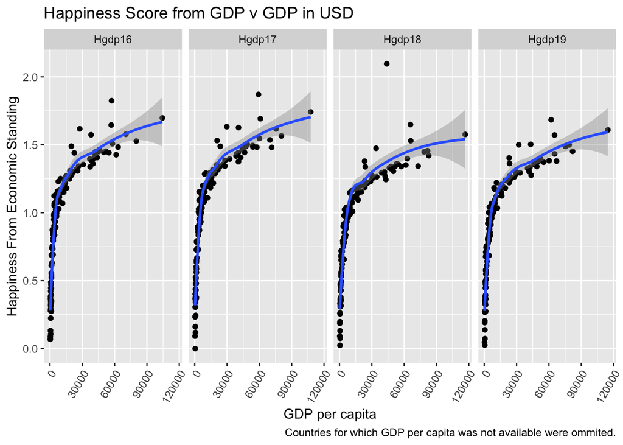

We can also see that throughout the countries for which we have data, GDP and happiness are strongly correlated, though there is more variation between countries, as we look at higher GDP per capita numbers. Our data supports the idea that making and having more money, even at the national scale, is correlated with having more happiness. In hindsight, this seems logical.

Of course, one consideration when deciding where to live is the potential for earnings and wealth accumulation. It logically follows that a country with a GDP per capita of at least $30,000/year would offers greater chances for obtaining happiness.

We also found that the general shape of the graph was relatively constant over the years measured. We know that it is hard to increase GDP more than a few percentage points per year so we can say that one would get the most happiness from living in a country where the GDP was the highest. Nevertheless, we will to be sure to check other factors as money is not the only thing that makes people happy!

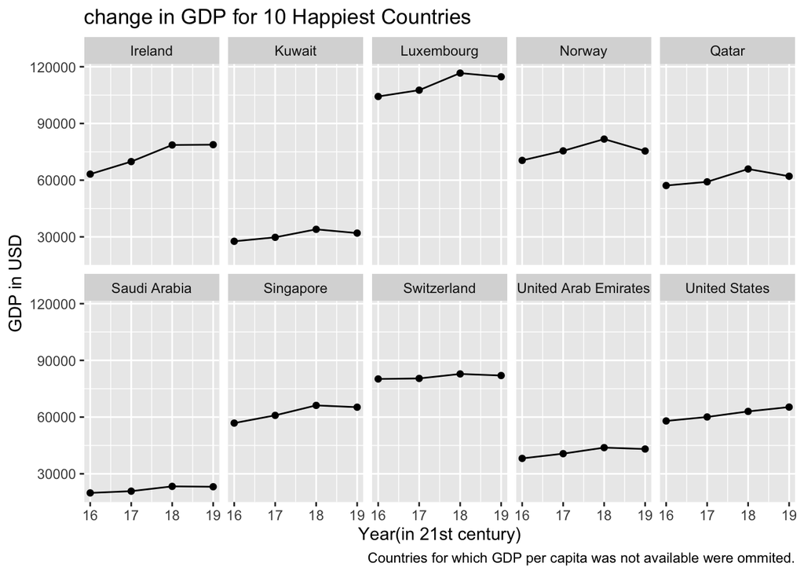

These dot plots show us that it would be hard to predict how a country’s GDP will change based on the happiness data, however, what we can see is that GDP per capita does not change drastically in a matter of years, as predicted. Therefore, the previous findings will be the only economic based criteria when picking a place to live; after 30K it would be wiser to make one’s choice of country based on the following factors.

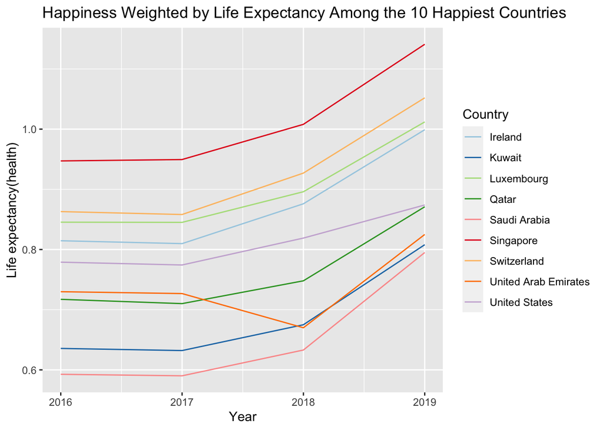

We see above that 2018 seems to have a peak in GDP per capita and thus we were curious as to whether we could see a similar trend in other facets of the happiness data. Indeed, we can see that from 2018 to 2019 the happiness derived from life expectancy increases dramatically.

In order to answer this question, we built a linear graph above called “Happiness Weighted by Life Expectancy Among the 10 Happiest Countries”, this graph plots health weighted happiness against health value time series. We can clearly see that among the ten happiest countries, the life expectancy impact on happiness increased for all countries from 2018 to 2019. Looking at United Arab Emirates from 2017 to 2018, the people in the United Arab Emirates actually believed their health was less essential that contributes to the calculation of the Happiness than before. The extent to which life expectancy contributed to the calculation of the Happiness fell from around 0.73 to 0.67. We can actually attribute this to the Yemen Airstrikes happened in the United Arab Emirates according to the 2018 world happiness report. Nevertheless, United Arab Emirates follwed the increasing trend of life expectancy. Although life expectancy and economic prosperity are major factors on a country’s aggregate happiness, they are not the only factors we should look at.

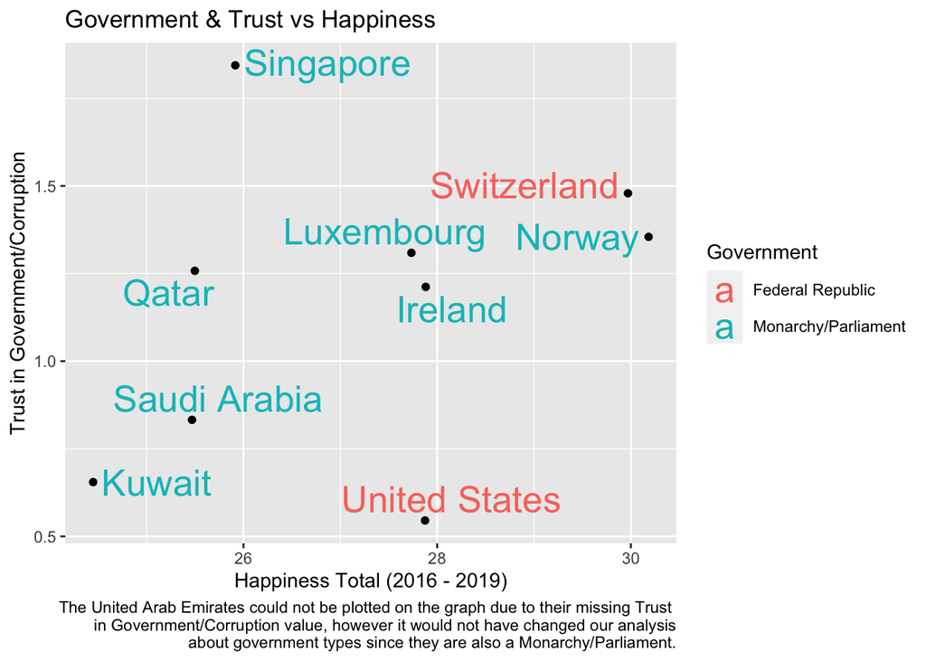

My initial hypothesis was that the happiest countries are using a democratic type of government. The world has seen what Democracy can do, such as give people freedom, connect nations with one another, and foster cooperation, instead of putting all the power under one person. With this amount of freedom, it could play a major role in determining a nation’s happiness score.

Based on the plot, the happiest nations seem to be ruled by a Monarchy/Parliamentary form of government. In other words, my initial guess was incorrect. Although a Democracy appears within the ten happiest countries, Monarchies come out on top each time. One conclusion that can definitely be made is that Communist states and nations with Military Dictatorship do not rank in the top 10. An interesting point to make is that although Switzerland is a Confederation/Direct Democracy and the United States is a Democracy, they are still able to place in the top 10. Thus, their happiness scores must have other factors making a larger impact. This could include: geographical location, the makeup of the population, advancements in technology, etc.

As a result, although the top 10 happiest countries share similar government types, how much they trust their own government is a different matter. The Trust in Government and Perception of Corruption variable plays a minor role in determining overall happiness. There are other factors, however, that contribute to the happiness score which people in this data set found to be more meaningful.

Central Intelligence Agency. (n.d.). Central Intelligence Agency. https://www.cia.gov/the-world-factbook/field/government-type/.

GDP per capita (current US$). Data. (n.d.). https://data.worldbank.org/indicator/NY.GDP.PCAP.CD.

Naval Ravikant Best 38 Quotes & Tweets on Wealth. (n.d.). https://mailbrew.com/library/naval-ravikant/top-tweets-on-wealth.

Network, S. D. S. (2019, November 27). World Happiness Report. Kaggle. https://www.kaggle.com/unsdsn/world-happiness.